# Procesamiento de datos

Residencia de Epidemiología

## Introducción

La manipulación de datos agrupa todas las tareas necesarias para la gestión de las variables:

- su transformación,
- la creación de nuevas variables,
- los cambios de escala,
- el formateo de categorías,
- el filtro de algunas observaciones, etc.,
- es decir, todo aquello que debamos hacer con los datos antes o durante el analisis.

## Paquete dplyr

[figure not shown]

- **dplyr** es el paquete para **transformar datos** que pertenece al ecosistema **tidyverse**
- Implementa una *gramática “humana”*
- Está constituido por funciones definidas como *“verbos”*
- Las funciones primarias son: `select()`, `filter()`, `arrange()`, `mutate()` y `summarise()`
- Otras funciones útiles son: `rename()`, `group_by()`, `count()`, `if_else()`, `case_when()`, `beteewn()`, `across()`, `rowwise()`, etc.

## select()

La función `select()` del inglés **seleccionar**, sirve para seleccionar variables (columnas) de una tabla de datos.

```r
select(datos, a, c)

datos |> select(a, c)
```

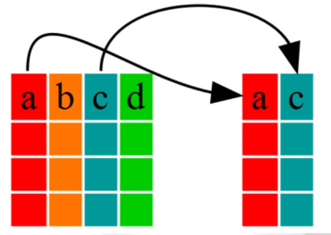

## Ayudantes de selección

Además existe un abanico de funciones que **ayudan** a una mejor selección de nombres de variables.

- `everything()`: coincide con todas las variables.
- `group_cols()`: seleccione todas las columnas de agrupación.
- `starts_with()`: comienza con un prefijo.
- `ends_with()`: termina con un sufijo.
- `contains()`: contiene una cadena literal.
- `matches()`: coincide con una expresión regular.
- `num_range()`: coincide con un rango numérico como x01, x02, x03.
- `all_of()`: coincide con nombres de variables en un vector de caracteres.
- `any_of()`: igual que `all_of()`, excepto que no se genera ningún error para los nombres que no existen.
- `where()`: aplica una función a todas las variables y selecciona aquellas para las cuales la función regresa TRUE.

## Ejemplo de select()

```
  [1] "Anio"              "Escuela"           "F1_FNac"
  [4] "F2_Edad"           "F3_Sexo"           "F4_Abuelos"
  [7] "F4_Hermanos"       "F4_Madrastra"      "F4_Madre"
 [10] "F4_Otros"          "F4_Padrastro"      "F4_Padre"
 [13] "F5_Amigo"          "F5_Familiar"       "F5_Nadie"
 [16] "F5_Novio"          "F5_Otro"           "F5_Profesional"
 [19] "F6_amigos"         "F7_Acompaniado"    "F8_novio"
 [22] "F9_CuantoTiempo"   "FKEY"              "GlobalRecordId"
 [25] "H1_Alcohol"        "H1_Bblancas"       "H1_Cerveza"
 [28] "H1_CuantosDias"    "H1_CuantosVasos"   "H1_Fernet"
 [31] "H1_Otra"           "H1_Vino"           "H2_Cigarrillos"
 [34] "H2_Cuantos"        "H3_Cuantos"        "H3_Marihuana"
 [37] "H4_Cual"           "H4_OtraDroga"      "H5_HoraDormir"
 [40] "H6_Almuerzo"       "H6_Cena"           "H6_Desayuno"
 [43] "H6_Merienda"       "H6_Motivado"       "H6A_Calle"
```

[output cut: 32 more lines]

```r
# seleccionamos solo variables que comienzan con "F5"
datos |>
  select(starts_with("F5")) |> names()
```

```
[1] "F5_Amigo"       "F5_Familiar"    "F5_Nadie"       "F5_Novio"
[5] "F5_Otro"        "F5_Profesional"
```

## rename()

La función `rename()` posibilita **renombrar** a las variables de una tabla de datos.

La estructura básica es:

```r
rename(datos, new_name = old_name)

datos |> rename(new_name = old_name)
```

La variación `rename_with()` permite **renombrar** variables de una tabla a través de aplicar determinadas funciones.

La estructura básica de esta función es:

```r
rename_with(datos, función, variables)

datos |> rename_with(función, variables)
```

## Ejemplo de rename() y rename_with()

```r
# renombramos F2_Edad por EDAD

datos |>
  rename(EDAD = F2_Edad)
```

```
[1] "EDAD"
```

```r
# renombramos el grupo de variables que comienza con F5
# por sus nombres en minúsculas

datos |>
  rename_with(.fn = tolower, .cols = starts_with("F5"))
```

```
[1] "f5_amigo"       "f5_familiar"    "f5_nadie"       "f5_novio"
[5] "f5_otro"        "f5_profesional"
```

## filter()

La función `filter()` del inglés **filtrar**, sirve para filtrar un subconjunto de observaciones (filas) de una tabla de datos a partir de una condición.

Para construir la condición se utilizan una serie de operadores de comparación y operadores lógicos similares a la de otros lenguajes de programación.

La estructura de la función puede ser cualquiera de las siguientes:

```r
filter(datos, condición)

datos |> filter(condición)
```

## Operadores de comparación

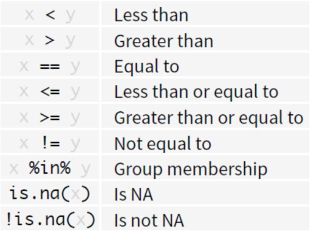

## Operadores lógicos (booleanos)

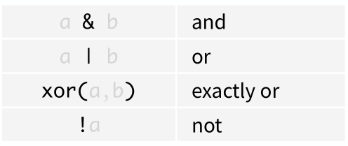

## Operadores lógicos (booleanos)

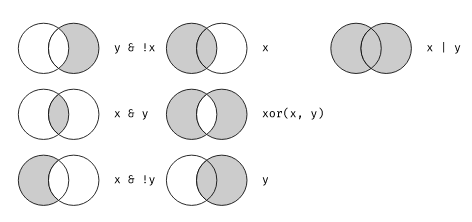

## Ejemplo de filter()

```r
# filtramos observaciones que cumplan con la siguiente condición
datos |>
  filter(F3_Sexo == 1,
         between(F2_Edad, 17, 20),
         H1_Cerveza == TRUE | H1_Vino == TRUE) |>
  select(F3_Sexo, F2_Edad, H1_Cerveza, H1_Vino)
```

```
# A tibble: 23 × 4
   F3_Sexo F2_Edad H1_Cerveza H1_Vino
     <dbl>   <dbl> <lgl>      <lgl>
 1       1      18 TRUE       FALSE
 2       1      17 TRUE       TRUE
 3       1      18 TRUE       FALSE
 4       1      17 TRUE       TRUE
 5       1      17 FALSE      TRUE
 6       1      19 TRUE       TRUE
 7       1      18 TRUE       TRUE
 8       1      17 TRUE       TRUE
 9       1      18 TRUE       TRUE
10       1      18 TRUE       TRUE
# ℹ 13 more rows
```

## arrange()

La función `arrange()` del inglés **ordenar**, sirve para ordenar observaciones de una tabla de datos a partir de una o más variables (columnas).

```r
arrange(datos, var1, var2, ...)

datos |> arrange(var1, var2, ...)
```

## arrange()

El ordenamiento *predeterminado* es *ascendente*.

Si la variable contiene números, las filas se van a ordenar ubicando esos números de menor a mayor (1,2,3…). Si es texto, las filas se van a ordenar ubicando las palabras alfabéticamente en forma ascendente (a,b,c…).

Si deseamos invertir el orden debemos incorporar la función **desc()** dentro de **arrange()**.

```r
datos |> arrange(var1)  # ascendente

datos |> arrange(desc(var1)) # descendente
```

## mutate()

La función `mutate()` del inglés **mutar o transformar**, sirve para crear nuevas variables, a partir de los valores de otras variables, dentro de la tabla de datos.

La o las nuevas variables creadas se incorporan al final de las columnas del conjunto de datos.

Dentro de los argumentos de `mutate()` se aplican funciones vectorizadas, lo que significa que la función toma un vector de valores como entrada y devuelve el mismo número de valores como salida.

```r
datos |> mutate(nueva_var = operación/función)
```

## mutate()

Algunas de las operaciones y funciones vectorizadas provistas por el lenguaje R son:

- Operadores aritméticos - **+**, **-**, *, **/**, **^**
- Aritmética modular - **%/%** - **%%**
- Transformación - escala - **log()** - **log2()** - **log10()** - **exp()** - **sqrt()**
- Comparaciones - **>**, **>=**, **<**, **<=**, **==**, **!=**
- Atrasos/adelantos - **lag()** - **lead()**
- Ordenamiento - **min_rank()** - **percent_rank()**, etc…
- Acumulativos - **cumsum()** - **cummean()** - etc…
- Condicional - **if_else()** - **case_when()**.

## Ejemplo de mutate()

```r
datos |> select(F1_FNac)
```

```
# A tibble: 1,252 × 1
   F1_FNac
   <chr>
 1 29/3/1999 00:00:00
 2 27/2/2003 00:00:00
 3 15/3/2000 00:00:00
 4 13/8/2001 00:00:00
 5 13/8/1998 00:00:00
 6 29/3/2001 00:00:00
 7 <NA>
 8 20/4/1997 00:00:00
 9 17/1/2001 00:00:00
10 27/8/2002 00:00:00
# ℹ 1,242 more rows
```

```r
datos |>
  mutate(F1_FNac = dmy_hms(F1_FNac),
         F1_FNac = as_date(F1_FNac)) |>
  select(F1_FNac)
```

```
# A tibble: 1,252 × 1
   F1_FNac
   <date>
 1 1999-03-29
 2 2003-02-27
 3 2000-03-15
 4 2001-08-13
 5 1998-08-13
 6 2001-03-29
 7 NA
 8 1997-04-20
 9 2001-01-17
10 2002-08-27
# ℹ 1,242 more rows
```

## summarise()

La función `summarise()` del inglés **resumir**, se utiliza justamente para resumir las observaciones de una tabla de datos mediante alguna *medida resumen*.

Otra forma de escribir la función es `summarize()`. Ambas realizan la misma operación.

```r
datos |> summarise(var_resumen = función_resumen)

datos |> summarize(var_resumen = función_resumen)
```

## summarise()

Algunas de las funciones resumen provistas por el lenguaje R son:

- tendencia central - **mean()** - **median()**
- posición - **min()** - **max()** - **quantile()**
- dispersión - **var()** - **sd()** - **IQR()**
- conteo - **n()** - **n_distinct()**
- orden - **first()** - **last()**

La mayoría de estas funciones aplican en tipos de datos int (enteros), dbl (reales), date (fecha) y ddtm (fecha - hora).

## Ejemplo de summarise()

```r
# Resumimos la variable F2_Edad calculando media,
# desvío estandar, mínimo y máximo

datos |>
  summarise(Media = mean(F2_Edad, na.rm = T),
            Desvio = sd(F2_Edad, na.rm = T),
            Min = min(F2_Edad, na.rm = T),
            Max = max(F2_Edad, na.rm = T))
```

```
# A tibble: 1 × 4
  Media Desvio   Min   Max
  <dbl>  <dbl> <dbl> <dbl>
1  14.5   1.46    10    19
```

## group_by()

La función `group_by()` del inglés **agrupar por**, sirve para agrupar a partir de valores o categorías distintas.

Aplicado sólo no produce ningún resultado interesante, por eso está pensando para usarlo principalmente asociado a **summarise()**.

```r
datos |> group_by(variable)
```

Junto a esta función aparece `ungroup()` que deshace el agrupamiento.

```r
datos |> ungroup()
```

## Ejemplo de group_by()

```r
# Resumimos la variable F2_Edad según Anio
# calculando media, desvío estandar, mínimo y máximo

datos |>
  group_by(Anio) |>
  summarise(Media = mean(F2_Edad, na.rm = T),
            Desvio = sd(F2_Edad, na.rm = T),
            Min = min(F2_Edad, na.rm = T),
            Max = max(F2_Edad, na.rm = T))
```

```
# A tibble: 2 × 5
  Anio  Media Desvio   Min   Max
  <chr> <dbl>  <dbl> <dbl> <dbl>
1 2do.   13.7   1.03    10    18
2 4to.   15.8   1.06    13    19
```

## Agrupamiento en summarise()

El agrupamiento o estratificación producido por `group_by()` es permanente mientras no desagrupemos y esto a veces ocasiona problemas.

En la última versión de **dplyr** se agregó un argumento en `summarise()` para lograr agrupamientos temporales, donde no hace falta desagrupar posteriomente al resultado.

```r
datos |> summarise(.by = variable_grupo)
```

## Ejemplo con .by en summarise()

```r
# Resumimos la variable F2_Edad según Anio con .by
# calculando media, desvío estandar, mínimo y máximo

datos |>
  summarise(Media = mean(F2_Edad, na.rm = T),
            Desvio = sd(F2_Edad, na.rm = T),
            Min = min(F2_Edad, na.rm = T),
            Max = max(F2_Edad, na.rm = T),
            .by = Anio)
```

```
# A tibble: 2 × 5
  Anio  Media Desvio   Min   Max
  <chr> <dbl>  <dbl> <dbl> <dbl>
1 4to.   15.8   1.06    13    19
2 2do.   13.7   1.03    10    18
```

## count()

La función `count()` del inglés **contar**, sirve para contabilizar categorías o valores diferentes de variables resumiendo los datos en una *tabla de frecuencia*.

Reconoce y también contabiliza los valores **NA** de las variables.

```r
datos |> count(variable)
```

Tiene algunos argumentos opcionales como:

- **name** (nombre de la variable que contabiliza - por defecto se llama n)
- **sort** (si es TRUE se ordena de mayor a menor)
- **wt** (variable peso / ponderación / expansión opcional)

También se pueden agregar más variables separadas por una coma.

## Ejemplo de count()

```r
# Contamos las frecuencias de la variable Anio
# ordenadas de mayor a menor

datos |>
  count(Anio, sort = T)
```

```
# A tibble: 2 × 2
  Anio      n
  <chr> <int>
1 2do.    750
2 4to.    502
```

## if_else()

La función `if_else()` devuelve valores dependiendo del resultado de una condición lógica (TRUE/FALSE).

Los valores devueltos para cada observación se almacenan dentro de una variable definida en **mutate()**.

```r
datos |>
  mutate(x = if_else(condicion, valor_T, valor_F))
```

## Ejemplo de if_else()

```r
datos |>
  summarise(Mediana_edad = median(F2_Edad, na.rm = T))
```

```
# A tibble: 1 × 1
  Mediana_edad
         <dbl>
1           14
```

```r
# dividimos en dos grupos según la mediana de edad
datos |>
  mutate(Grupo_edad = if_else(F2_Edad <= 14, "<= 14", "> 14")) |>
  count(Grupo_edad)
```

```
# A tibble: 3 × 2
  Grupo_edad     n
  <chr>      <int>
1 <= 14        597
2 > 14         583
3 <NA>          72
```

## case_when()

La función `case_when()` ejecuta una vectorización múltiple de funciones `if_else()`.

Los valores devueltos para cada observación se almacenan dentro de una variable definida en `mutate()`.

```r
datos |>
  mutate(x = case_when(
    condicion ~ valor_T,
    ...,
    .default = valor))
```

## Ejemplo de case_when()

```r
# etiquetamos la variable V1_Alegre
datos |>
  mutate(V1_Alegre = case_when(
    V1_Alegre == 0 ~ "Nada",
    V1_Alegre == 1 ~ "Poco",
    V1_Alegre == 2 ~ "Neutral",
    V1_Alegre == 3 ~ "Muy",
    V1_Alegre == 4 ~ "Totalmente",
    .default = "Ns/Nc"
  )) |>
  count(V1_Alegre, sort = T)
```

```
# A tibble: 6 × 2
  V1_Alegre      n
  <chr>      <int>
1 Totalmente   452
2 Muy          256
3 Neutral      249
4 Ns/Nc        171
5 Poco          80
6 Nada          44
```

## between()

La función `between()` es una función atajo para operaciones de condición *>=* x *<=* , implementado para vectores numéricos o de fecha/hora.

Se utiliza dentro de estructuras donde se escriben condiciones (`filter()`, `mutate()`, etc).

```r
datos |> filter(between(x, izquierda, derecha))
```

Los dos extremos (izquierda y derecha) se incluyen en el intervalo

## Ejemplo de between()

```r
# filtramos observaciones donde la variable F2_Edad sea mayor
# o igual a 16 y menor o igual 18 años

datos |>
 filter(between(F2_Edad, 16, 18)) |>
  count(F2_Edad)
```

```
# A tibble: 3 × 2
  F2_Edad     n
    <dbl> <int>
1      16   153
2      17    95
3      18    29
```

## Documentación

[figure not shown]

Capítulo 3 del libro [“R for Data Science (2e)”](https://r4ds.hadley.nz/data-transform)